# 第1回 ガイダンス

明日、何台用意する？——データ解析を一周してみる

# 第1部 この授業の進め方

## この授業で、何ができるようになるか

- 14回かけて、**回帰 → 分類 → 教師なし学習**を一通り体験する
- 題材は毎回ちがう分野の**実データ**——交通・医療・画像・社会経済・映画……
- ゴールは、データを渡されたときに**自分で問いを立て、解析を実行し、答えを言える**こと

今日はその一周目。**自転車シェアのデータ**で、問いを立ててから答えるまでを最後まで通します。

## なぜ `fit()` 一行で済ませないのか

- ライブラリを使えば、`model.fit()` の一行で結果は出る
- でも中身を知らないと、**結果が正しいか判断できない**し、**うまくいかないとき直せない**
- 間違った結果ほど、もっともらしい顔をして出てくる

だからこの授業では、**まず最も基礎的な計算から実行してみて、それから道具で答え合わせ**をします。

## 1回の流れ

1. スライドで、**小さな問い**を1つ立てる
2. **やってみよう**：Colab のノートで、その問いに答えるセルを実行する
3. **答え合わせ**：Colab の画面で、何が出れば正解かを確かめる
4. 1〜3 を何度か回し、最後に**課題を LACS に提出**（＝出席。期限なし）

動画で見ている人は、「やってみよう」のところで**動画を一時停止**して、ノートを実行してください。

## なぜ、環境づくりは大変なのか

- Python の道具（パッケージ）は、**互いのバージョンに依存**している
- パッケージ A を新しくしたら、B が対応しておらず**インストールに失敗**——はよくある話
- だから実務や研究では、解析プロジェクトごとに**環境を分けて**作る
  - **コンテナ**（Docker・Apptainer）や、**Anaconda の仮想環境**

## だから、この授業は Colab

- 主要なパッケージが**最初からそろった環境**を、Google が用意している
- ブラウザを開くだけで、**全員が同じ環境**になる。環境づくりでつまずかない
- Azure や AWS と違い、**無料の範囲**で使える。上限に達しても一時的に使えなくなるだけで、**勝手に課金されない**

## Colab①：ノートを開く

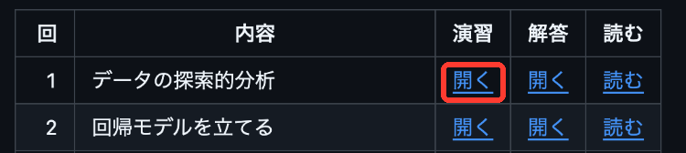

- 教材ページ（GitHub）の表から、その回の「演習」列の**［開く］**をクリック
- ブラウザの中で、Google Colab にノートが開きます。インストールもデータのダウンロードも要りません

## Colab②：ドライブにコピーする

[figure not shown]

- 開いた直後のノートは**借り物**。書き込んでも**保存されません**
- ［ファイル］→［ドライブにコピーを保存］（上の帯の［ドライブにコピー］でも同じ）で、**自分のノート**にしてから始めます

## Colab③：セルを実行する

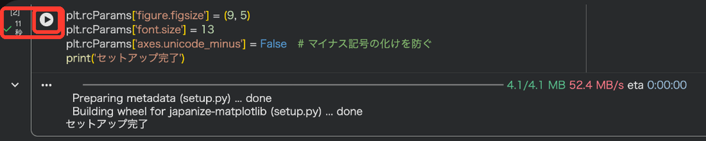

- ノートは**セル**の並び。文章のセルと、コードのセルがある
- コードのセルは、左の **▶** か **Shift + Enter** で実行。結果がすぐ下に出て、終わると左に **✓** が付く
- 最初の1回は、Colab の準備と道具の取り寄せで**十数秒**かかります

## プログラムは上から下へ

- 1つのセルの中は、**上の行から順に**実行される
- ノートも、**上のセルから順に**実行する。前のセルで作ったものを、後のセルで使うから
- Colab は実行したことを覚えている。逆に、**まだ実行していないセルは、無いのと同じ**

迷ったら、**いちばん上から順に**実行し直す。これが基本です。

## エラーは怖くない

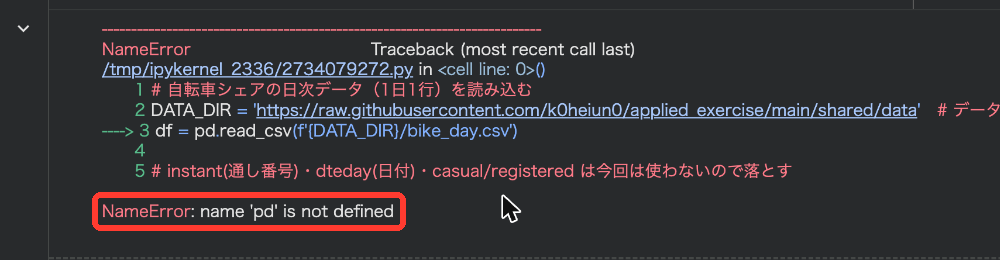

- 赤い表示が出たら、**いちばん下の行**を読む。原因はたいていそこに書いてある
- よく出る3つ：**NameError**（上のセルを飛ばした）／**ModuleNotFoundError**（道具が入っていない）／**SyntaxError**（打ち間違い）

## やってみよう：Colab を動かす

- 第1回のノートを**開いて**、**ドライブにコピー**する
- 「最初に実行する：道具を呼び出す設定のセル」の次にあるコードのセルを **▶** で実行する
- 十数秒待って、**「セットアップ完了」**と出れば成功

**動画の人は、ここで一時停止。** 終わったら再開しましょう。

## 答え合わせ：セットアップ完了

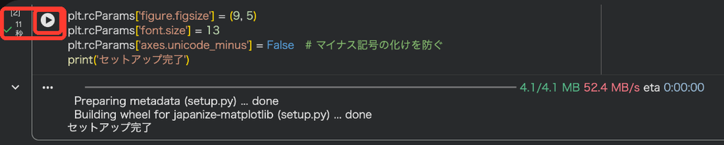

- 左に **✓** と実行にかかった秒数、下に **「セットアップ完了」** が出ていれば OK
- 赤いエラーが出たら、いちばん下の行を読み、もう一度 ▶ を押してみましょう

# 第2部 明日、何台用意する？

## あなたは、自転車シェアの運営者

- 街のあちこちに自転車を置き、**借りて乗り捨て**てもらうサービス
- 自転車が足りなければ客を逃し、余れば置き場と整備のむだになる
- 毎晩決めなければならないのは——**明日、何台用意すればいいか**

今日の問い：**明日の利用台数に、数字で見当をつけたい**

## この問いに、どう近づくか

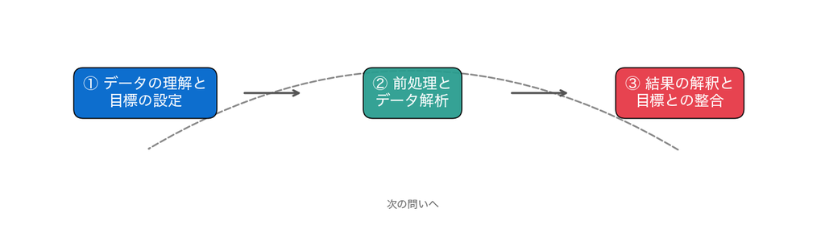

データ分析は、**①データを知って問いを定める → ②解析する → ③答えを確かめる**の輪を回ります。今日は小さく**一周**します。

# ① データを知る

## 表を読むための道具：ライブラリ

```python
import pandas as pd
```

- 表を読む機能は、Python 本体には入っていない。**ライブラリ**という道具を足して使う
- ライブラリは**パッケージ**という単位で配られ、**pip install** で取り寄せる（Colab にはよく使うものが最初から入っている）
- `import pandas as pd` で呼び出す。`pd` は略称。さっきの設定のセルでは、表の pandas と図の matplotlib・seaborn を呼び出しました

## どんなデータが、手元にあるか

```python
df = pd.read_csv(f'{DATA_DIR}/bike_day.csv')
df = df.drop(columns=['instant', 'dteday', 'casual', 'registered'])
print(f'行数: {df.shape[0]}, 列数: {df.shape[1]}')
df.head()
```

- `pd.read_csv(...)` は「pandas の read_csv」という**関数**。CSV ファイルの表を読む
- `df = ...` は、右で読んだ表を左の名前 `df` にしまう書き方（**変数**）
- `df.head()` のように `df.` に続けて書くのは、表が持っている機能（**メソッド**）の呼び出し
- 答えの内訳（`casual`＋`registered`＝台数）などの列は、今回は落とします

## やってみよう：1節

- 「1. データの読み込み」のコードのセルを実行する
- 表の**行数と列数**、先頭5行の中身を見る
- 1行は何を表しているか？ 当てたい列はどれか？ を考えながら

**動画の人は、ここで一時停止。**

## 答え合わせ：1行が1日、731日

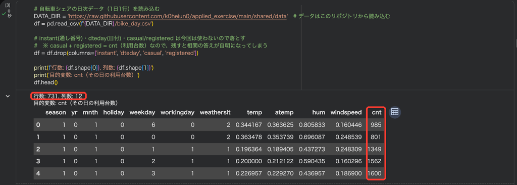

- **731行・12列**。1行が1日の記録で、約2年ぶんの毎日が並ぶ
- 当てたいのは最後の **cnt（その日の利用台数）**。ほかの列はその日の季節・天気・気温など

## 1日の台数は、どれくらい振れる？

```python
df.describe().round(2)
```

- `describe()` は、各列の**要約**（件数・平均・ばらつき・最小・最大など）を一度に出す
- 見るところ：**cnt** の平均と最小・最大。それと、**よく似た数字の並ぶ列**がないか
- 計算の前に、**欠けた値（空欄）**がないかも確かめておく（3節）

## TODO を埋める

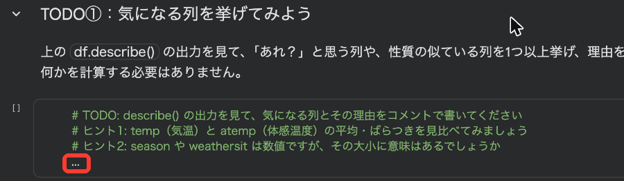

- **TODO** のセルにある `...` が、あなたが書く場所。何を書くかは、セルの前の文章にある
- セルの中の「**ヒント**」のコメントも手がかりに
- それでも動かないときは［ランタイム］→［**ランタイムを再起動**］→［**すべてのセルを実行**］

## やってみよう：2〜3節と TODO①

- 2節の `describe` と、3節の欠損値の確認を実行する
- **TODO①**：`describe` の出力を見て、「あれ？」と思う列や、よく似た列を挙げ、理由をコメントに書く

**動画の人は、ここで一時停止。**

## 答え合わせ：振れ幅とクセ

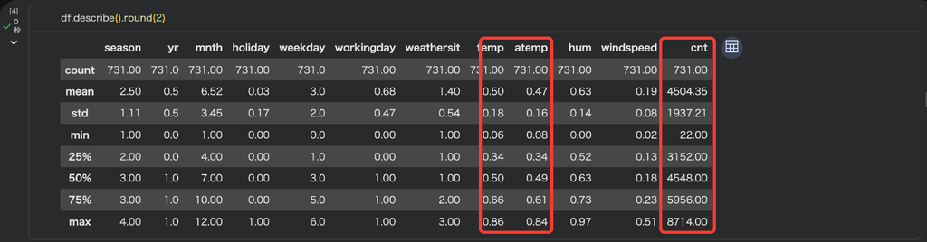

## 答え合わせ：TODO① と欠損値

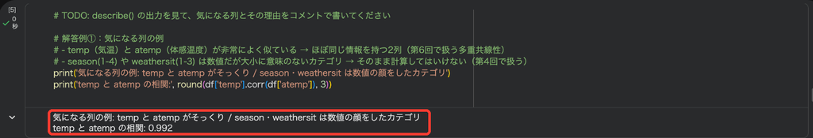

- temp と atemp の相関は **0.99**。同じ情報が2列ある（第6回で、係数を暴れさせる原因として扱う）
- season や weathersit は数字だが**大小に意味のない区分**（第4回で扱う）
- 欠けた値は**どの列も0個**。実務のデータでは普通にあるので、第4回で扱います

## 台数と手がかりは、どんな形か

- 数字の要約だけでは、**形**は分からない。図にして見る
- **ヒストグラム**：1つの列の値が、どこに多く集まっているか
- **散布図**：2つの列の関係。点の散らばりに、右上がりや頭打ちが見える

見るのは3つ——**台数の形**、**手がかりの形**、**台数と手がかりの関係**。

## やってみよう：4〜6節と TODO②

- 4節（台数の分布）と5節（手がかりの分布）の図を描く
- **TODO②**：手がかりの列を1つ選び、`plt.scatter(df['列名'], df['cnt'], alpha=0.3, s=8)` で散布図を描く
- 迷ったら **temp**（気温）を選んでみよう

**動画の人は、ここで一時停止。**

## 答え合わせ：台数の形

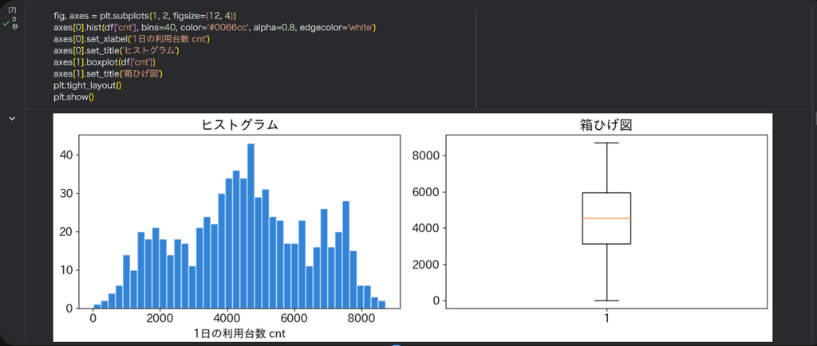

- 山は1つで、なだらかに広がる。**極端に偏った日の集まりはない**
- 平均で考えても、大きく外れにくい形です

## 答え合わせ：手がかりの形

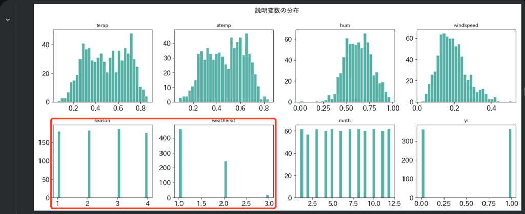

- 赤枠の **season・weathersit** は、棒がとびとびに立つだけ——**区分**の列だと形でも分かる
- weathersit の 3（悪天候）は、ごくわずか

## 答え合わせ：気温と台数

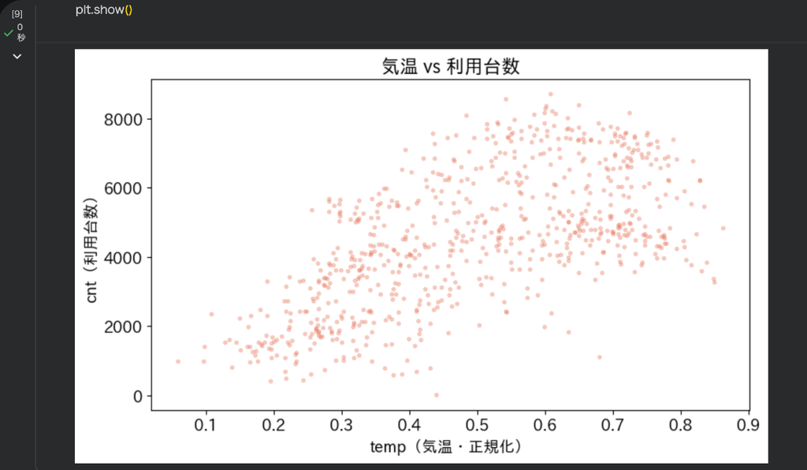

- **暖かい日ほど多い**、右上がりの関係
- ただし右端（暑すぎる日）では**頭打ち**で、少し減っている

## どれが、いちばん効きそうか

- 列はたくさんある。散布図を全部描いて見比べるのは大変
- **相関係数**：2つの列が一緒に動く度合いを、−1〜1 の1つの数にしたもの
- `df.corr(numeric_only=True)` で全部の組み合わせを計算し、**cnt との相関**を強い順に並べる

## やってみよう：7節と TODO③

- 7節の相関行列（色つきの表）を描く
- **TODO③**：`df.corr(numeric_only=True)['cnt']` から、cnt との相関が高い**上位3つ**を取り出す
- ヒント：`.drop('cnt')` と `.sort_values(ascending=False)`

**動画の人は、ここで一時停止。**

## 答え合わせ：相関行列

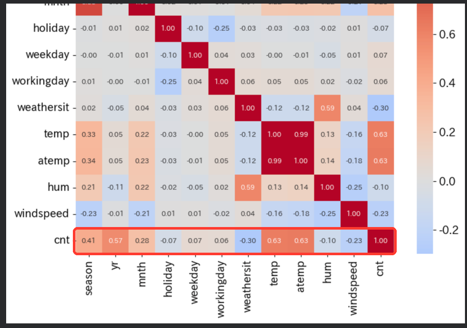

- いちばん下の **cnt の行**を横に読む。赤いほど「一緒に増える」、青いほど「逆に動く」
- temp・atemp（0.63）と yr（0.57）が濃い赤

## 答え合わせ：上位3つ

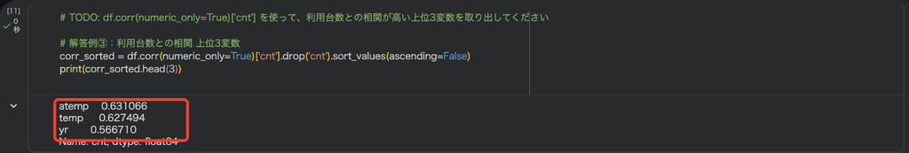

- 上位は **atemp・temp（0.63）**、**yr（0.57）**
- 手がかりは**気温**と**年**。そっくりな2列がほぼ同点で並ぶのは当然です

## 問いを、データで答えられる形に

- 「明日何台？」に、いきなり答える式はまだない
- でも、こう言い換えれば計算できる——**明日と条件が似た日は、過去に何台だったか**
- 似た日の平均を答えにすればいい。条件には、見つけた手がかり（**気温・年**）から使っていきます

# ② 平均で当ててみる

## まず、何も考えずに答えると

```python
pred = df['cnt'].mean()                          # 毎日「全体の平均」と答える
print(round((df['cnt'] - pred).abs().mean()))    # 外れ幅の平均
```

- どの日にも「平均の台数」と答えたら、どれだけ外れるか
- 実際が3000台の日に4504台と答えたら、1504台の外れ。多すぎても少なすぎても、**ずれの大きさ**だけを見る
- その大きさを全日で平均したものを、**外れ幅の平均**と呼ぶ。これが手がかりの価値を測る**基準**

## 気温帯で分けて、平均する

```python
df['気温帯'] = pd.cut(df['temp'] * 41, bins=[0, 10, 15, 20, 25, 30, 40])
df.groupby('気温帯', observed=True)['cnt'].agg(['mean', 'count']).round(0)
pred = df.groupby('気温帯', observed=True)['cnt'].transform('mean')
```

- `temp` は 0〜1 に縮めてあるので、41 を掛けて℃に戻し、5℃刻みの**気温帯**に分ける（`pd.cut`）
- `groupby` で、同じ気温帯の日をまとめて平均する
- `transform('mean')` で、その平均を1日1日に配り直し、**その日の答え**にする

## 年でも、天気でも分ける

```python
for keys in [['気温帯', 'yr'], ['気温帯', 'yr', 'weathersit']]:
    pred = df.groupby(keys, observed=True)['cnt'].transform('mean')
    print(keys, '→ 外れ幅の平均:', round((df['cnt'] - pred).abs().mean()), '台')
```

- `groupby` に列の**リスト**を渡すと、条件の**組み合わせ**でグループができる
- 気温帯×年、気温帯×年×天気で、外れ幅がどう変わるかを見る

## やってみよう：8節の前半

- 「8. 平均で明日を当ててみる」の最初から、「年でも分ける」のセルまで実行する
- 外れ幅の平均が、**基準 → 気温帯 → 気温帯×年 → 天気も**で、どう縮むかを記録する

**動画の人は、ここで一時停止。**

## 答え合わせ：基準は1582台

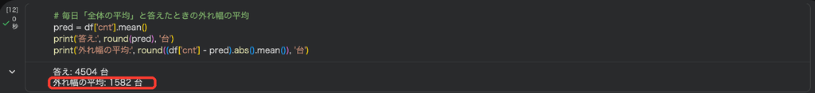

- 毎日「4504台」と答えると、外れ幅の平均は **1582台**
- ここから、どれだけ縮められるか

## 答え合わせ：気温帯で1211台

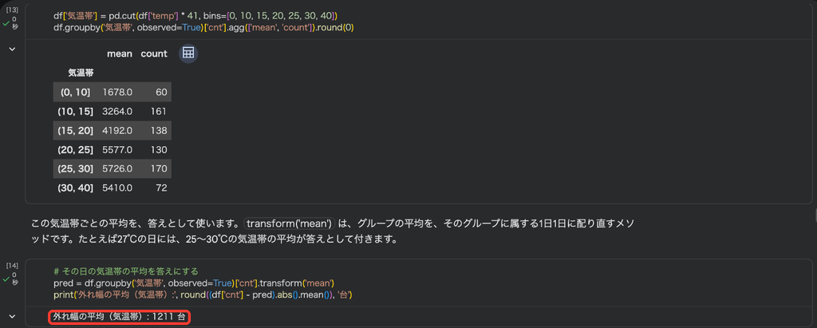

- 10℃以下は平均 **1678台**、25〜30℃は **5726台**。3倍以上ちがう
- 気温帯の平均で答えると、外れ幅は **1582台 → 1211台**

## 答え合わせ：年も分けて762台

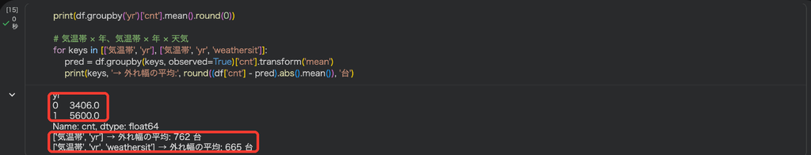

- 1年目 **3406台** → 2年目 **5600台**。同じ気温でも、2年目のほうが多い
- 気温帯×年で **762台**。基準からほぼ**半分**。天気も足すと **665台**——縮み方は小さくなってきた

## あなたの番：外れ幅を縮めよう

- 分ける列を自分で選んで、外れ幅の平均を**どこまで縮められるか**
- 使える列：`気温帯`・`season`・`yr`・`mnth`・`holiday`・`weekday`・`workingday`・`weathersit`
- `keys = ['気温帯', 'yr', 'season']` のように並べ、前のセルと同じ計算をする

いちばん小さくなった組み合わせと、その外れ幅を記録しておこう。

## やってみよう：TODO④

- **TODO④** のセルに、自分の `keys` と外れ幅の計算を書いて実行する
- 組み合わせを変えて、何度か試す。**665台**より小さくできるか？
- 早く終わった人は、列を4つ、5つと増やしてみよう

**動画の人は、ここで一時停止。**

## 答え合わせ：TODO④ の例

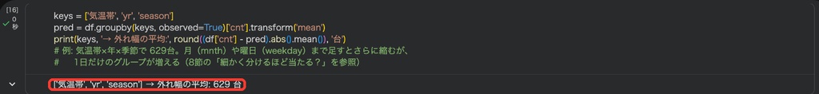

- 例：気温帯×年×季節で **629台**
- 月（`mnth`）や曜日（`weekday`）まで足すと、もっと縮む。では、どこまでも縮めていいのか？

## 細かく分けるほど、当たる？

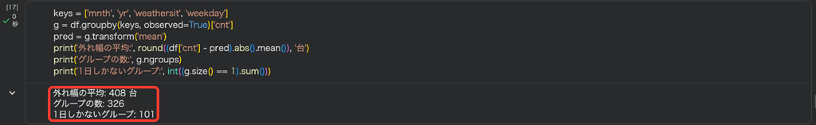

- 月×年×天気×曜日で、外れ幅は **408台**まで縮んだ
- でも **326グループのうち101グループは、1日しかない**

## 1日だけのグループの正体

- 1日だけのグループの「平均」は、**その日の台数そのもの**
- つまりその日は、**自分自身の台数を答えにして採点している**。外れ幅が0なのは当然
- 今日の採点は、すべて**平均を作るのに使った日**で行っている。まだ来ていない明日で試したら？

細かく分けるほど、見かけの外れ幅は小さくなる。**本当の実力をどう測るか**は、第3回で扱います。

# ③ 答えを確かめる

## 運営者への答え

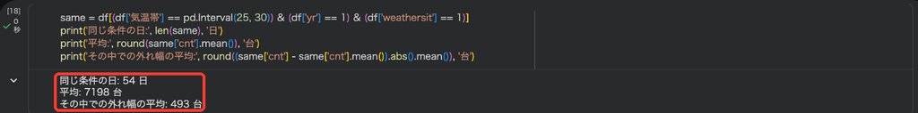

- 細かくしすぎない**気温帯×年×天気**で答える。明日が **25〜30℃・2年目・晴れ**なら、同じ条件の日は **54日**、平均 **7198台**
- その54日の中でも、外れ幅の平均は **493台**

答え：**「およそ7200台。500台くらいは前後しうる」**——数字で見当がつきました。

## まだ言えないこと

- **本当の実力は分からない**：作るのに使った日で採点している。未来の日で試すと？ → 第3回
- **段がガタガタ**：24.9℃と25.1℃で答えが跳ぶ。気温を入れると台数が出る**1本の式**が欲しい → 第2回
- **グループが足りない**：条件を足すほど、1つのグループの日数が減って平均が頼りなくなる

## 「暖かいから増える」と言えるか

- 暖かい日ほど多い——でも、**気温を上げれば客が増える**とは言い切れない
- 夏は気温も高く、日も長く、休みも多い。**季節**が、気温と台数を同時に動かしているかもしれない
- 今日の平均は「**似た日はこうだった**」という手がかり。原因の証明ではありません

## 今日、一周した

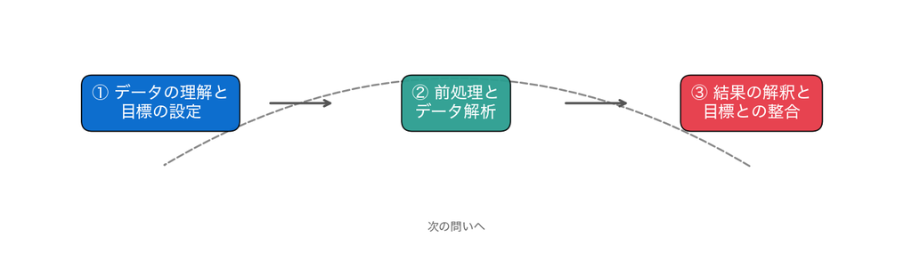

①データを知って問いを「似た日は何台？」に言い換え、②条件ごとの平均で当て、③外れ幅で確かめて答えた。**輪を一周**しました。

## 今日の要点

- 大きな問い（明日何台？）は、**データで答えられる形**（似た日は何台だった？）に言い換える
- 当てる前に、台数と手がかりの**形とクセ**を図で見ておく。相関は手がかりで、因果の証明ではない
- 答える前に**基準**（毎日平均と答えたら1582台外れる）を置くと、手がかりの価値が測れる。気温帯×年で**762台**
- 細かく分けすぎると、**自分自身を答えにして採点**してしまう。見かけの外れ幅は、本当の実力より甘い

## 課題の出し方

- ノートの最後にある **課題（提出）** に取り組む。時刻ごとの利用台数を集計する問題です
- **応用②の答え**と**応用③の文章**を、**LACS** に入力して提出
- AI を使ってかまいません。その代わり、**何を聞いて、返ってきたものをどう直したか**を1行書きます

提出が出席の記録です。授業に出られなかった回も、動画とノートで取り組んで後から出せます。

## 次回予告：この段を、1本の式に

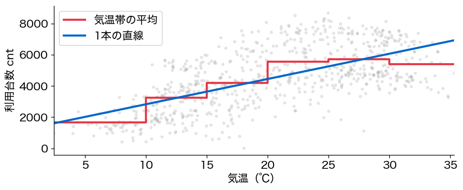

ガタガタの段を、**1本の式**にしたい。第2回は、その式を**最も基礎的な計算から**立てます。——でも、直線でいいのでしょうか？

## このあと：課題へ

- ノートの **課題（提出）** を解いて、LACS に提出する——これで第1回は完了
- 時間が余った人は、**発展（任意）**：データの自動レポートを作ってみよう
- わからなくなったら、ノートの「**Colab と Python の使い方**」を見返そう